# Milestone 2 Example Key

## Setting Up

For this milestone, you will:

- Finalize hypotheses
- Run two of your final analyses & interpret the results
- Create a visualization for each of your hypothesis results
- Create a table for each of your hypothesis results

For this key, I will use the `palmerpenguins` dataset to complete the exercises.

My advice to you: look over your Milestone 1 and any comments I left for you on the assignment.

### Libraries

```r
library(tidyverse)
library(ggplot2)
library(psych)
library(viridis)
library(interactions)
library(palmerpenguins)
library(apaTables)
library(kableExtra)
```

### Data: Pick a dataset

On Canvas, there is a folder with available datasets to pick for the final project. Spend some time going through them and select one that you want to work on this semester.

#### EXERCISE 1: Load Your Data

In the code chunk below, load in your .csv dataset. Then, use `glimpse()` to take a peek.

```r
glimpse(penguins)
```

```
## Rows: 344
## Columns: 8
## $ species           <fct> Adelie, Adelie, Adelie, Adelie, Adelie, Adelie, Adel…
## $ island            <fct> Torgersen, Torgersen, Torgersen, Torgersen, Torgerse…
## $ bill_length_mm    <dbl> 39.1, 39.5, 40.3, NA, 36.7, 39.3, 38.9, 39.2, 34.1, …
## $ bill_depth_mm     <dbl> 18.7, 17.4, 18.0, NA, 19.3, 20.6, 17.8, 19.6, 18.1, …
## $ flipper_length_mm <int> 181, 186, 195, NA, 193, 190, 181, 195, 193, 190, 186…
## $ body_mass_g       <int> 3750, 3800, 3250, NA, 3450, 3650, 3625, 4675, 3475, …
## $ sex               <fct> male, female, female, NA, female, male, female, male…
## $ year              <int> 2007, 2007, 2007, 2007, 2007, 2007, 2007, 2007, 2007…
```

## Research Questions

#### EXERCISE 2: Finalize your Research Questions & Hypotheses

For the final project you will run 4 analyses: a correlation, a t-test, and 2 different multiple regressions.

If I did not leave any feedback/suggestions for you to change your research questions & you want to keep them, you can use the exact same ones from Milestone 1. Make sure to add a hypothesis.

**Correlation Research Question:** Come up with a correlation research question. As a reminder, a correlation looks at the relationship between two numeric variables. What are two numeric variables that you think could be related? In what way would they be related?

**Question:** Are bill length and bill depth positively related? Both are independent variables.

**Hypothesis:** I hypothesize that bill length and bill depth will be positively correlated with eachother.

**T-Test Research Question:** Come up with a t-test research question. A t-test compares two different groups on a numeric variables. For example, I could look at if there is a difference in male versus female penguins (independent variable) on how much they weigh (dependent variable). My research question would be: Do male penguins weigh more than female penguins? T-Tests can **only** compare two different groups (not 3+).

**Question:** Do male penguins weigh more than female penguins? Penguin sex is the independent variable. Penguin weight is the dependent variable.

**Hypothesis:** I hypothesize that male penguins weigh more than female penguins.

**Multiple Regression Research Questions:** Come up with two different multiple regression research questions. A regression as a numeric variable as a dependent variable. A Multiple regression is a regression that has 2 or more independent variables. I suggest sticking only to 2 or three independent variables. For example, I could look at if penguin species (independent variable 1) and penguin island (independent variable 2) impact penguin body mass (dependent variable).

**Question 1:** Do penguin species (independent variable 1) and penguin island (independent variable 2) impact penguin body mass (dependent variable)?

**Hypothesis:** I hypothesize that Gentoo penguins from Biscoe island will be the heaviest penguins.

**Question 2:** Do penguin species (independent variable 1) and penguin island (independent variable 2) impact penguin flipper length (dependent variable)?

**Hypothesis:** I hypothesize that Adelie penguins from Dream Island will have the longest flippers.

## Descriptive Statistics

#### EXERCISE 3: Expore your Variables

In exercise 2, you identified all of your variables for the final project within the research questions.

**Numeric Variables:** For your numeric variables, use the `describe()` function from the `psych` library.

**Categorical Variables:** For your categorical variables, use the `table()` function to get a frequency table.

```r
describe(penguins$body_mass_g)
```

```
##    vars   n    mean     sd median trimmed    mad  min  max range skew kurtosis
## X1    1 342 4201.75 801.95   4050 4154.01 889.56 2700 6300  3600 0.47    -0.74
##       se
## X1 43.36
```

```r
describe(penguins$flipper_length_mm)
```

```
##    vars   n   mean    sd median trimmed   mad min max range skew kurtosis   se
## X1    1 342 200.92 14.06    197  200.34 16.31 172 231    59 0.34       -1 0.76
```

```r
describe(penguins$bill_length_mm)
```

```
##    vars   n  mean   sd median trimmed  mad  min  max range skew kurtosis  se
## X1    1 342 43.92 5.46  44.45   43.91 7.04 32.1 59.6  27.5 0.05    -0.89 0.3
```

```r
describe(penguins$bill_depth_mm)
```

```
##    vars   n  mean   sd median trimmed  mad  min  max range  skew kurtosis   se
## X1    1 342 17.15 1.97   17.3   17.17 2.22 13.1 21.5   8.4 -0.14    -0.92 0.11
```

```r
table(penguins$species)
```

```
##
##    Adelie Chinstrap    Gentoo
##       152        68       124
```

```r
table(penguins$island)
```

```
##
##    Biscoe     Dream Torgersen
##       168       124        52
```

```r
table(penguins$sex)
```

```
##
## female   male
##    165    168
```

## Analyses

For this milestone you must run two of your final analyses. For example, you can run a correlation and a t-test, or two multiple regressions, or any other combinaton of analyses. For this key I will be running all 4 analyses.

### Analysis 1

#### EXERCISE 4: Run Your Analysis

For my first analysis I will run a correlation.

Note: After you run the correlation, interpret the results in APA format.

```r
cor.test(penguins$bill_length_mm, penguins$bill_depth_mm)
```

```
##
##  Pearson's product-moment correlation
##
## data:  penguins$bill_length_mm and penguins$bill_depth_mm
## t = -4.4591, df = 340, p-value = 1.12e-05
## alternative hypothesis: true correlation is not equal to 0
## 95 percent confidence interval:
##  -0.3328072 -0.1323004
## sample estimates:
##        cor
## -0.2350529
```

There is a significant negative correlation between the bill depth and bill length of penguins, r(340) = -.24, p < .001.

#### EXERCISE 5: Graphing

Now, create a graph for the analysis you just ran.

I just ran a correlation and therefore I will create a scatterplot.

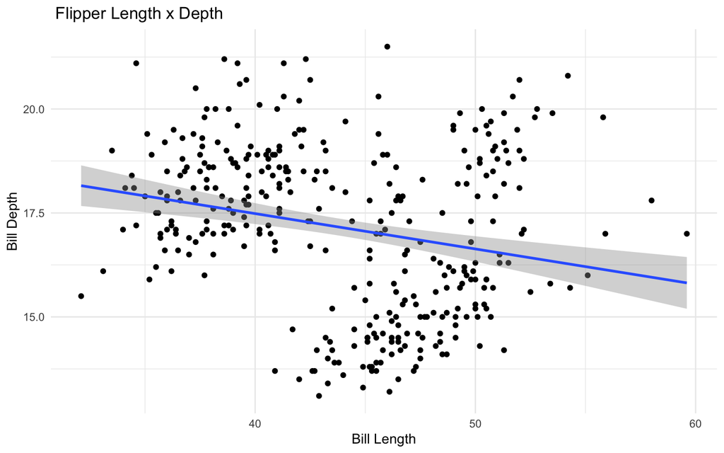

```r
ggplot(penguins, aes(bill_length_mm, bill_depth_mm)) +
  geom_point() +
  theme_minimal() +
  geom_smooth(method = "lm") +
  labs(x = "Bill Length", y = "Bill Depth", title = " Flipper Length x Depth")
```

#### EXERCISE 6: Visualization Interpretation

In the space below, write 1-2 sentences interpreting what you learned from the the previous graph.

#### EXERCISE 7: Table

Next, create a table for the analysis you just ran.

```r
penguins.small <- penguins %>%
  select(c(bill_depth_mm, bill_length_mm))

cor.table <- apa.cor.table(penguins.small)

cor.table$table.body %>%
  kable(booktabs = TRUE)
```

Variable

M

SD

1

1. bill_depth_mm

17.15

1.97

2. bill_length_mm

43.92

5.46

-.24**

[-.33, -.13]

### Analysis 2

#### EXERCISE 8: Run Your Analysis

For my second analysis I will run a t-test.

Note: After you run the t-test, interpret the results in APA format.

```r
t.test(body_mass_g ~ sex, penguins)
```

```
##
##  Welch Two Sample t-test
##
## data:  body_mass_g by sex
## t = -8.5545, df = 323.9, p-value = 4.794e-16
## alternative hypothesis: true difference in means between group female and group male is not equal to 0
## 95 percent confidence interval:
##  -840.5783 -526.2453
## sample estimates:
## mean in group female   mean in group male
##             3862.273             4545.685
```

There is a significant difference between the weight of male versus female penguins, with male penguins weighing more, t(323.9) = -8.55, p < .001.

#### EXERCISE 9: Graphing

Now, create a graph for the analysis you just ran.

I just ran a t-test and therefore I will create a bar graph.

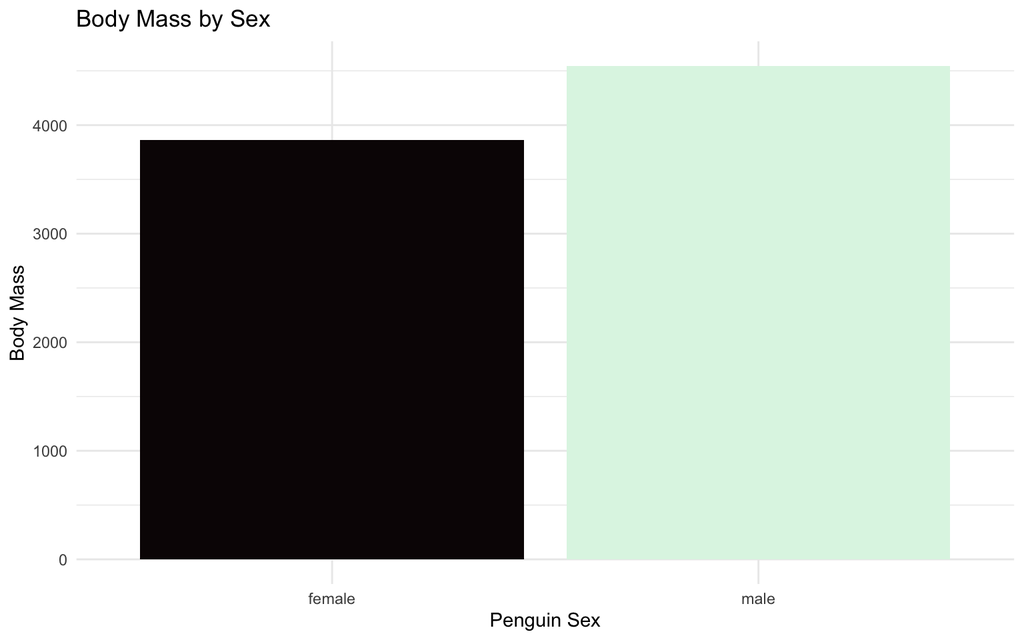

```r
ggplot(penguins %>% filter(!is.na(sex)), aes(sex, body_mass_g, fill = sex)) +
  stat_summary(fun = "mean", geom = "bar", position = "dodge") +
  theme_minimal()  +
  labs(x = "Penguin Sex", y = "Body Mass", title = "Body Mass by Sex") +
  guides(fill = "none") +
  scale_fill_viridis_d(option = "mako")
```

#### EXERCISE 10: Visualization Interpretation

In the space below, write 1-2 sentences interpreting what you learned from the the previous graph.

#### EXERCISE 11: Table

Next, create a table for the analysis you just ran.

For a t-test, we will want to create a table showing the means and sd of male versus female penguins on body mass.

```r
penguins %>%
  filter(!is.na(sex)) %>%
  group_by(sex) %>%
  summarize(Mean = mean(body_mass_g, na.rm = T),
            SD = sd(body_mass_g, na.rm = T))%>%
  kable(booktabs = TRUE)
```

| sex | Mean | SD |
| --- | --- | --- |
| female | 3862.273 | 666.1720 |
| male | 4545.685 | 787.6289 |

### Bonus Analysis 3

#### Run Your Analysis

For my third analysis I will run a multiple regression.

Note: After you run the regression, interpret the results in APA format.

```r
#Do penguin species (independent variable 1) and penguin island (independent variable 2) impact penguin body mass (dependent variable)?

#I hypothesize that Gentoo penguins from Biscoe island will be the heaviest penguins.

penguins$species <- relevel(penguins$species, ref = "Gentoo")

mod.1 <- lm(body_mass_g ~ species*island, penguins)
summary(mod.1)
```

```
##
## Call:
## lm(formula = body_mass_g ~ species * island, data = penguins)
##
## Residuals:
##      Min       1Q   Median       3Q      Max
## -1126.02  -333.09   -33.09   316.91  1223.98
##
## Coefficients: (4 not defined because of singularities)
##                                   Estimate Std. Error t value Pr(>|t|)
## (Intercept)                       5076.016     41.801 121.432   <2e-16 ***
## speciesAdelie                    -1366.357     81.437 -16.778   <2e-16 ***
## speciesChinstrap                 -1321.662    116.750 -11.320   <2e-16 ***
## islandDream                        -21.266     93.395  -0.228    0.820
## islandTorgersen                     -3.287     95.388  -0.034    0.973
## speciesAdelie:islandDream               NA         NA      NA       NA
## speciesChinstrap:islandDream            NA         NA      NA       NA
## speciesAdelie:islandTorgersen           NA         NA      NA       NA
## speciesChinstrap:islandTorgersen        NA         NA      NA       NA
## ---
## Signif. codes:  0 '***' 0.001 '**' 0.01 '*' 0.05 '.' 0.1 ' ' 1
##
## Residual standard error: 463.6 on 337 degrees of freedom
##   (2 observations deleted due to missingness)
## Multiple R-squared:  0.6697, Adjusted R-squared:  0.6658
## F-statistic: 170.8 on 4 and 337 DF,  p-value: < 2.2e-16
```

#### Graphing

Now, create a graph for the analysis you just ran.

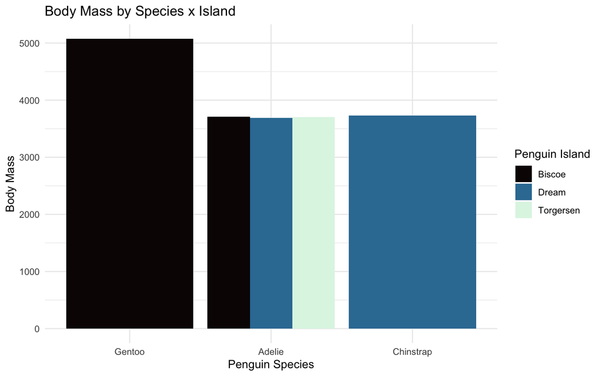

```r
ggplot(penguins, aes(species, body_mass_g, fill = island)) +
  stat_summary(fun = "mean", geom = "bar", position = "dodge") +
  theme_minimal()  +
  labs(x = "Penguin Species", y = "Body Mass", fill = "Penguin Island", title = "Body Mass by Species x Island") +
  scale_fill_viridis_d(option = "mako")
```

#### Table

Next, create a table for the analysis you just ran.

```r
reg.table <- apa.reg.table(mod.1)

reg.table$table_body %>%
  kable(booktabs = TRUE)
```

| Predictor | b | b_95%_CI | sr2 | sr2_95%_CI | Fit |
| --- | --- | --- | --- | --- | --- |
| (Intercept) | 5076.02** | [4993.79, 5158.24] |  |  |  |
| speciesAdelie | -1366.36** | [-1526.55, -1206.17] | .28 | [.21, .34] |  |
| speciesChinstrap | -1321.66** | [-1551.31, -1092.01] | .13 | [.08, .17] |  |
| islandDream | -21.27 | [-204.98, 162.44] | .00 | [-.00, .00] |  |
| islandTorgersen | -3.29 | [-190.92, 184.34] | .00 | [-.00, .00] |  |
| speciesAdelie:islandDream | NA | [NA, NA] | NA | [NA, NA] |  |
| speciesChinstrap:islandDream | NA | [NA, NA] | NA | [NA, NA] |  |
| speciesAdelie:islandTorgersen | NA | [NA, NA] | NA | [NA, NA] |  |
| speciesChinstrap:islandTorgersen | NA | [NA, NA] | NA | [NA, NA] |  |
|  |  |  |  |  | R2 = .670** |
|  |  |  |  |  | 95% CI[.61,.71] |

### Bonus Analysis 4

#### Run Your Analysis

For my fourth analysis I will run a multiple regression.

Note: After you run the regression, interpret the results in APA format.

```r
#**Question 2:** Do penguin species (independent variable 1) and penguin island (independent variable 2) impact penguin flipper length (dependent variable)?

#**Hypothesis:** I hypothesize that Adelie penguins from Dream Island will have the longest flippers.

penguins$species <- relevel(penguins$species, ref = "Adelie")
penguins$island <- relevel(penguins$island, ref = "Dream")


mod.2 <- lm(flipper_length_mm ~ species*island, penguins)
summary(mod.2)
```

```
##
## Call:
## lm(formula = flipper_length_mm ~ species * island, data = penguins)
##
## Residuals:
##      Min       1Q   Median       3Q      Max
## -17.8235  -4.7321  -0.1961   4.1975  18.8039
##
## Coefficients: (4 not defined because of singularities)
##                                  Estimate Std. Error t value Pr(>|t|)
## (Intercept)                      189.7321     0.8859 214.157  < 2e-16 ***
## speciesGentoo                     28.3915     1.1646  24.378  < 2e-16 ***
## speciesChinstrap                   6.0914     1.1964   5.092 5.92e-07 ***
## islandBiscoe                      -0.9367     1.3356  -0.701    0.484
## islandTorgersen                    1.4639     1.2833   1.141    0.255
## speciesGentoo:islandBiscoe             NA         NA      NA       NA
## speciesChinstrap:islandBiscoe          NA         NA      NA       NA
## speciesGentoo:islandTorgersen          NA         NA      NA       NA
## speciesChinstrap:islandTorgersen       NA         NA      NA       NA
## ---
## Signif. codes:  0 '***' 0.001 '**' 0.01 '*' 0.05 '.' 0.1 ' ' 1
##
## Residual standard error: 6.63 on 337 degrees of freedom
##   (2 observations deleted due to missingness)
## Multiple R-squared:  0.7803, Adjusted R-squared:  0.7777
## F-statistic: 299.2 on 4 and 337 DF,  p-value: < 2.2e-16
```

#### Graphing

Now, create a graph for the analysis you just ran.

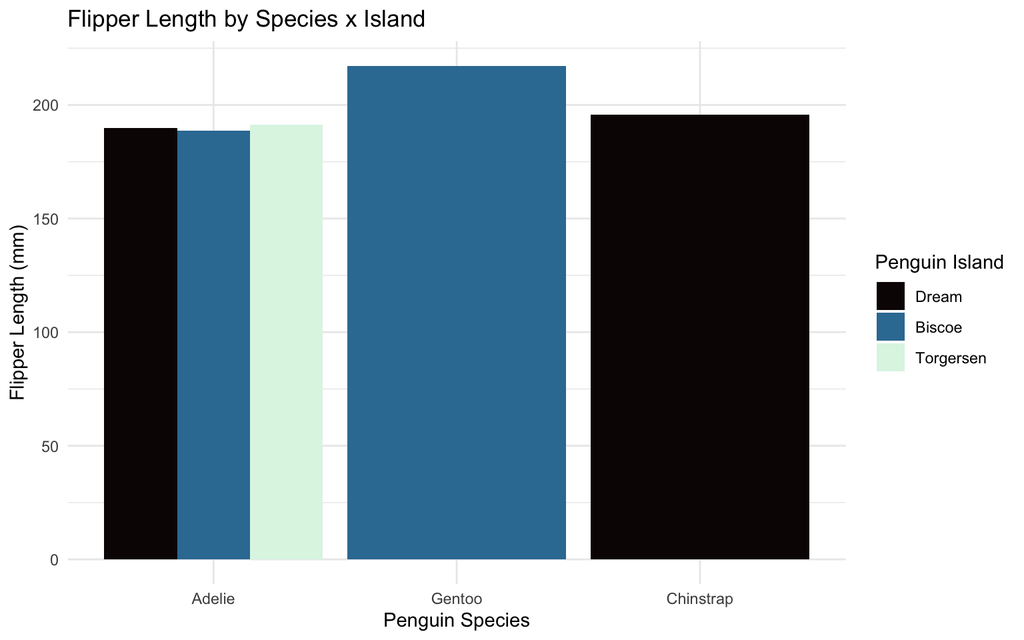

```r
ggplot(penguins, aes(species, flipper_length_mm, fill = island)) +
  stat_summary(fun = "mean", geom = "bar", position = "dodge") +
  theme_minimal()  +
  labs(x = "Penguin Species", y = "Flipper Length (mm)", fill = "Penguin Island", title = "Flipper Length by Species x Island") +
  scale_fill_viridis_d(option = "mako")
```

#### Table

Next, create a table for the analysis you just ran.

```r
reg.table.2 <- apa.reg.table(mod.2)

reg.table.2$table_body %>%
  kable(booktabs = TRUE)
```

| Predictor | b | b_95%_CI | sr2 | sr2_95%_CI | Fit |
| --- | --- | --- | --- | --- | --- |
| (Intercept) | 189.73** | [187.99, 191.47] |  |  |  |
| speciesGentoo | 28.39** | [26.10, 30.68] | .39 | [.32, .46] |  |
| speciesChinstrap | 6.09** | [3.74, 8.44] | .02 | [.00, .03] |  |
| islandBiscoe | -0.94 | [-3.56, 1.69] | .00 | [-.00, .00] |  |
| islandTorgersen | 1.46 | [-1.06, 3.99] | .00 | [-.00, .00] |  |
| speciesGentoo:islandBiscoe | NA | [NA, NA] | NA | [NA, NA] |  |
| speciesChinstrap:islandBiscoe | NA | [NA, NA] | NA | [NA, NA] |  |
| speciesGentoo:islandTorgersen | NA | [NA, NA] | NA | [NA, NA] |  |
| speciesChinstrap:islandTorgersen | NA | [NA, NA] | NA | [NA, NA] |  |
|  |  |  |  |  | R2 = .780** |
|  |  |  |  |  | 95% CI[.74,.81] |